# Classification and regression trees

Author

Maciej Beręsewicz

# 1 Packages

**R**

```r
install.packages("rpart")
install.packages("rpart.plot")
install.packages("partykit")
```

```r
library(rpart)
library(rpart.plot)
library(partykit)
set.seed(123)
```

**Python**

```bash
!pip install scikit-learn matplotlib
```

```python
import numpy as np
import pandas as pd
import matplotlib.pyplot as plt
from sklearn.tree import DecisionTreeRegressor, DecisionTreeClassifier, plot_tree
from sklearn.linear_model import LinearRegression, LogisticRegression
np.random.seed(123)
```

**Julia**

```julia
using Pkg
Pkg.add(["DecisionTree", "GLM", "DataFrames", "CSV", "CategoricalArrays",
         "Statistics", "Random", "Plots", "Distributions"])
```

```julia
using DecisionTree
using GLM
using DataFrames
using CSV
using CategoricalArrays
using Statistics
using Random
using Distributions
Random.seed!(123);
```

# 2 Why trees?

A classification or regression tree approximates $f(\mathbf{x}) = E[Y \mid X = \mathbf{x}]$ by a **piecewise-constant** function on a partition of the predictor space. This notebook walks through four examples of increasing complexity:

1. continuous $Y$ with one continuous $X$ that has a non-linear shape – OLS vs. a regression tree;
2. binary $Y$ with one continuous $X$ – logistic regression vs. a classification tree;
3. binary $Y$ with one binary $X$ pair – where the response is an interaction (XOR-style);
4. the real Polish Job Vacancy Survey – reproducing the toy tree from the slides.

After each example there is a short exercise.

# 3 Example 1 – continuous $Y$, continuous $X$ (non-linear)

The data-generating process is
$$Y_i = \sin(2\pi X_i) + \varepsilon_i, \qquad X_i \sim U(0, 1), \qquad \varepsilon_i \sim N(0, 0.3^2).$$

The true regression function is smooth and non-monotone. OLS in $X$ alone can only fit a line; the tree carves the $X$-axis into intervals and predicts the mean of $Y$ on each.

**R**

```r
n <- 300
x <- runif(n)
y <- sin(2 * pi * x) + rnorm(n, sd = 0.3)
d1 <- data.frame(x = x, y = y)
```

```r
fit_lm   <- lm(y ~ x, data = d1)
fit_tree <- rpart(y ~ x, data = d1,
                  method = "anova",                ## "anova" = regression tree (SSR splits); use "class" for classification
                  control = rpart.control(
                    cp       = 0.01,               ## complexity threshold: refuse a split unless it cuts the (scaled) error by >= cp
                    minsplit = 20))                ## a node with fewer than 20 obs is never split
```

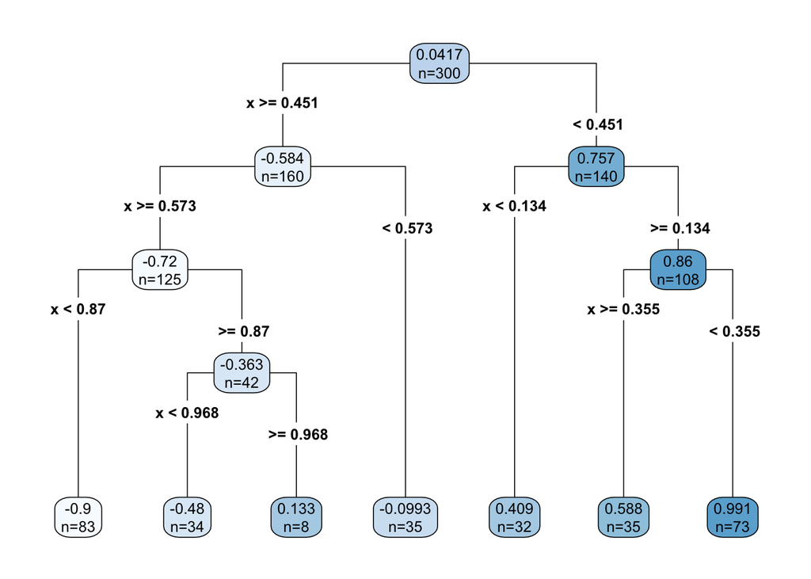

```r
rpart.plot(fit_tree, type = 4, extra = 1, digits = 3)
```

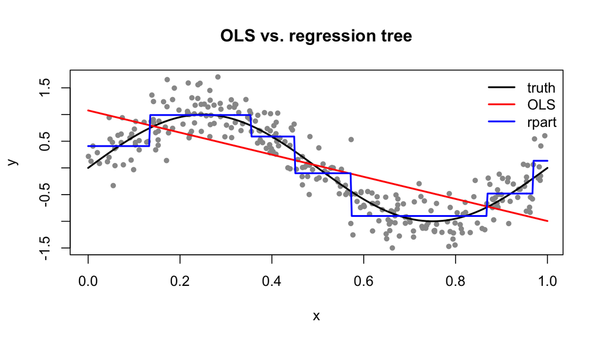

```r
xs <- seq(0, 1, length = 400)
yhat_lm   <- predict(fit_lm,   newdata = data.frame(x = xs))
yhat_tree <- predict(fit_tree, newdata = data.frame(x = xs))

plot(x, y, pch = 19, col = "grey60", cex = 0.7,
     xlab = "x", ylab = "y", main = "OLS vs. regression tree")
lines(xs, sin(2 * pi * xs), col = "black", lwd = 2)
lines(xs, yhat_lm,   col = "red",  lwd = 2)
lines(xs, yhat_tree, col = "blue", lwd = 2)
legend("topright",
       legend = c("truth", "OLS", "rpart"),
       col    = c("black", "red", "blue"),
       lwd = 2, bty = "n")
```

In-sample MSE:

```r
c(OLS  = mean((d1$y - predict(fit_lm))^2),
  tree = mean((d1$y - predict(fit_tree))^2))
```

```
       OLS       tree
0.29682661 0.08633418
```

**Python**

```python
n = 300
x = np.random.uniform(0, 1, n)
y = np.sin(2 * np.pi * x) + np.random.normal(0, 0.3, n)
X = x.reshape(-1, 1)
```

```python
fit_lm   = LinearRegression().fit(X, y)
fit_tree = DecisionTreeRegressor(
    max_depth         = 4,   ## hard cap on tree depth; None = grow until pure
    min_samples_split = 20   ## a node with fewer than 20 obs is never split
).fit(X, y)
```

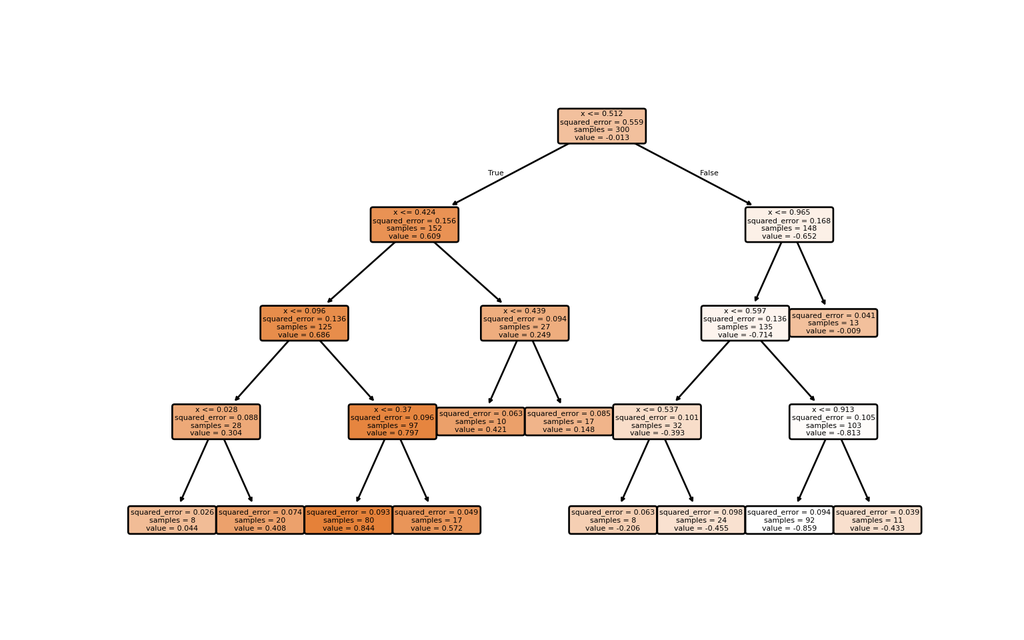

```python
fig, ax = plt.subplots(figsize = (8, 5))
plot_tree(fit_tree, filled = True, rounded = True, feature_names = ["x"], ax = ax)
plt.show()
```

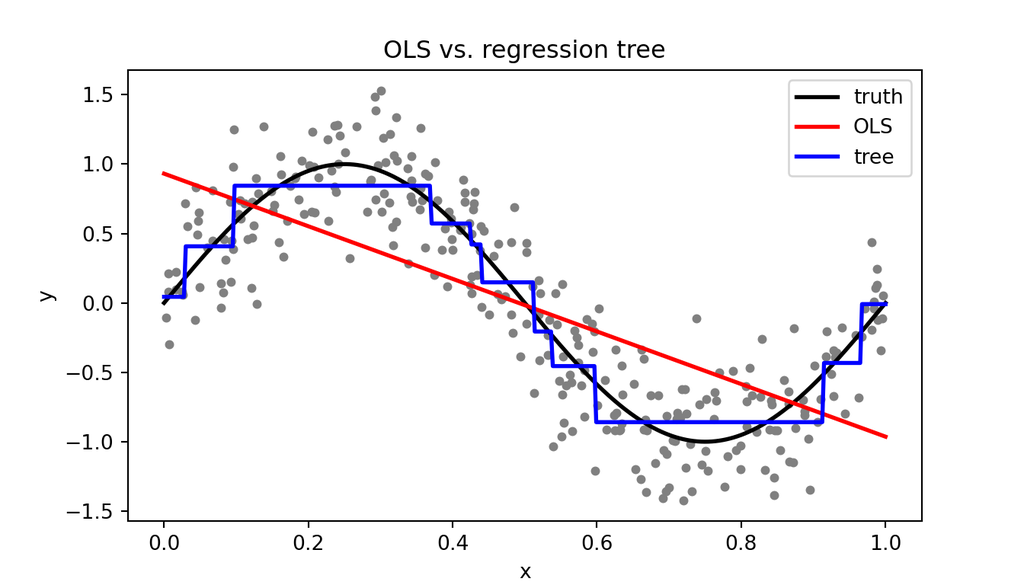

```python
xs = np.linspace(0, 1, 400).reshape(-1, 1)
plt.figure(figsize = (7, 4))
plt.scatter(x, y, color = "grey", s = 12)
plt.plot(xs, np.sin(2 * np.pi * xs),  color = "black", lw = 2, label = "truth")
plt.plot(xs, fit_lm.predict(xs),      color = "red",   lw = 2, label = "OLS")
plt.plot(xs, fit_tree.predict(xs),    color = "blue",  lw = 2, label = "tree")
plt.xlabel("x"); plt.ylabel("y"); plt.legend(); plt.title("OLS vs. regression tree")
plt.show()
```

```python
{"OLS":  float(((y - fit_lm.predict(X))**2).mean()),
 "tree": float(((y - fit_tree.predict(X))**2).mean())}
```

```
{'OLS': 0.2736821844346108, 'tree': 0.08151752311093353}
```

**Julia**

```julia
n = 300;
x = rand(n);
y = sin.(2 * pi .* x) .+ randn(n) .* 0.3;
X = reshape(x, n, 1);
```

```julia
fit_lm   = lm(@formula(y ~ x), DataFrame(x = x, y = y));
fit_tree = DecisionTreeRegressor(
    max_depth         = 4,    ## hard cap on tree depth; -1 = grow until pure
    min_samples_split = 20    ## a node with fewer than 20 obs is never split
);
DecisionTree.fit!(fit_tree, X, y);
```

```julia
print_tree(fit_tree, 3)
```

```
Feature 1 < 0.5315 ?
├─ Feature 1 < 0.4178 ?
    ├─ Feature 1 < 0.07877 ?
        ├─
        └─
    └─ Feature 1 < 0.4627 ?
        ├─ 0.31650801842097315 : 0/15
        └─ 0.056941209283036566 : 0/16
└─ Feature 1 < 0.8874 ?
    ├─ Feature 1 < 0.6043 ?
        ├─
        └─
    └─ Feature 1 < 0.9399 ?
        ├─ -0.46465686305274284 : 0/17
        └─ -0.07172820528817377 : 0/16
```

```julia
yhat_lm   = GLM.predict(fit_lm);
yhat_tree = DecisionTree.predict(fit_tree, X);
(OLS  = mean((y .- yhat_lm).^2),
 tree = mean((y .- yhat_tree).^2))
```

```
(OLS = 0.28813936250207617, tree = 0.0853199652927483)
```

The tree fits a step function that follows the sine curve, while OLS misses the shape almost entirely. The in-sample MSE for the tree is much smaller – the cost is a piecewise-constant fit with visible discontinuities at the splits.

## 3.1 Exercise 1

Replace the sine wave with a **quadratic** trend, $Y_i = (X_i - 0.5)^2 + \varepsilon_i$, with the same noise level. Refit OLS and a regression tree. Two questions:

1. Does the tree still help, or does plain OLS now suffice?
2. Add the squared term $X^2$ to the OLS formula. How does its in-sample MSE compare to the tree’s?

# 4 Example 2 – binary $Y$, continuous $X$

The DGP has a **non-monotone** success probability:
$$P(Y_i = 1 \mid X_i) \;=\; \tfrac{1}{2} + 0.4 \cdot \sin(2\pi X_i), \qquad X_i \sim U(0, 1).$$

A plain logistic regression in $X$ alone is constrained to a monotone S-curve and will fail to recover the bumps; a classification tree splits $X$ into bins matching the high- and low-probability regions.

**R**

```r
n <- 500
x <- runif(n)
p <- 0.5 + 0.4 * sin(2 * pi * x)
y <- rbinom(n, size = 1, prob = p)
d2 <- data.frame(x = x, y = factor(y))
```

```r
fit_logit <- glm(y ~ x, data = d2, family = binomial())
fit_ctree <- rpart(y ~ x, data = d2,
                   method = "class",                ## "class" = classification tree (Gini splits by default)
                   control = rpart.control(
                     cp        = 0.005,             ## smaller cp than the default 0.01 -> allow a deeper tree
                     minbucket = 20))               ## every leaf must contain at least 20 obs
```

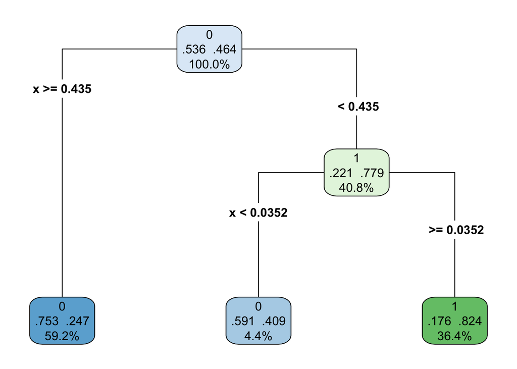

```r
rpart.plot(fit_ctree, type = 4, extra = 104, digits = 3)
```

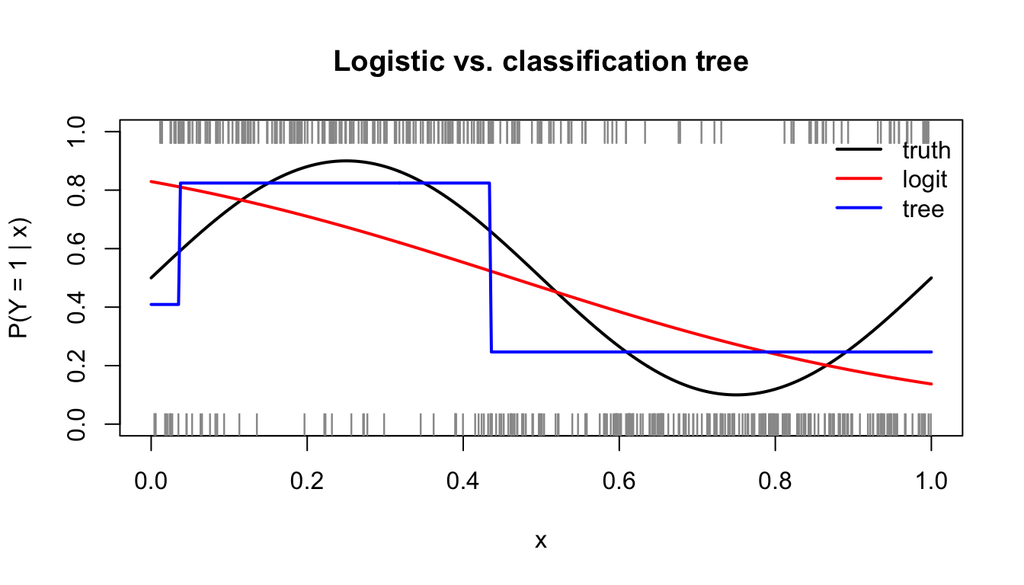

```r
xs <- seq(0, 1, length = 400)
p_logit <- predict(fit_logit, newdata = data.frame(x = xs), type = "response")
p_tree  <- predict(fit_ctree, newdata = data.frame(x = xs), type = "prob")[, "1"]

plot(xs, 0.5 + 0.4 * sin(2 * pi * xs),
     type = "l", lwd = 2, ylim = c(0, 1),
     xlab = "x", ylab = "P(Y = 1 | x)", main = "Logistic vs. classification tree")
lines(xs, p_logit, col = "red",  lwd = 2)
lines(xs, p_tree,  col = "blue", lwd = 2)
points(x, as.numeric(as.character(d2$y)), pch = "|", col = "grey60")
legend("topright",
       legend = c("truth", "logit", "tree"),
       col    = c("black", "red", "blue"),
       lwd = 2, bty = "n")
```

In-sample classification error:

```r
err_logit <- mean((predict(fit_logit, type = "response") > 0.5) != (d2$y == "1"))
err_tree  <- mean(predict(fit_ctree, type = "class") != d2$y)
c(logit = err_logit, tree = err_tree)
```

```
logit  tree
0.248 0.228
```

**Python**

```python
n = 500
x = np.random.uniform(0, 1, n)
p = 0.5 + 0.4 * np.sin(2 * np.pi * x)
y = np.random.binomial(1, p)
X = x.reshape(-1, 1)
```

```python
fit_logit = LogisticRegression().fit(X, y)
fit_ctree = DecisionTreeClassifier(
    max_depth        = 4,    ## hard cap on tree depth
    min_samples_leaf = 20    ## every leaf must contain at least 20 obs
).fit(X, y)
```

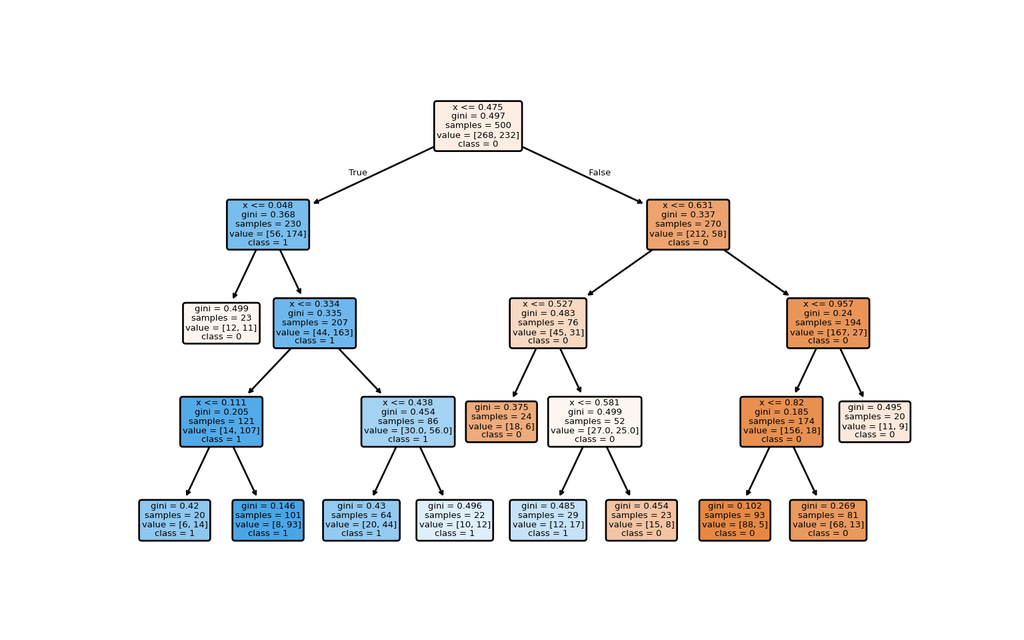

```python
fig, ax = plt.subplots(figsize = (8, 5))
plot_tree(fit_ctree, filled = True, rounded = True,
          feature_names = ["x"], class_names = ["0", "1"], ax = ax)
plt.show()
```

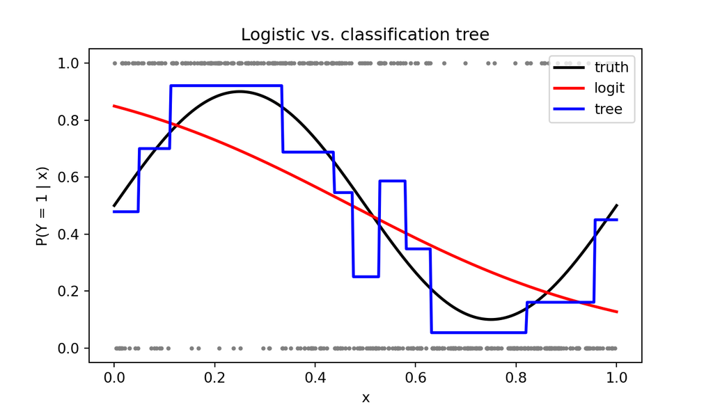

```python
xs = np.linspace(0, 1, 400).reshape(-1, 1)
plt.figure(figsize = (7, 4))
plt.plot(xs, 0.5 + 0.4 * np.sin(2 * np.pi * xs.ravel()),
         color = "black", lw = 2, label = "truth")
plt.plot(xs, fit_logit.predict_proba(xs)[:, 1], color = "red",  lw = 2, label = "logit")
plt.plot(xs, fit_ctree.predict_proba(xs)[:, 1], color = "blue", lw = 2, label = "tree")
plt.scatter(x, y, color = "grey", s = 4)
plt.xlabel("x"); plt.ylabel("P(Y = 1 | x)"); plt.legend()
plt.title("Logistic vs. classification tree")
plt.show()
```

```python
{"logit": float((fit_logit.predict(X) != y).mean()),
 "tree":  float((fit_ctree.predict(X) != y).mean())}
```

```
{'logit': 0.228, 'tree': 0.216}
```

**Julia**

```julia
n = 500;
x = rand(n);
p = 0.5 .+ 0.4 .* sin.(2 * pi .* x);
y = Int.(rand(n) .< p);
X = reshape(x, n, 1);
```

```julia
fit_logit = glm(@formula(y ~ x), DataFrame(x = x, y = y), Binomial(), LogitLink());
fit_ctree = DecisionTreeClassifier(
    max_depth        = 4,     ## hard cap on tree depth
    min_samples_leaf = 20     ## every leaf must contain at least 20 obs
);
DecisionTree.fit!(fit_ctree, X, y);
```

```julia
print_tree(fit_ctree, 3)
```

```
Feature 1 < 0.5157 ?
├─ Feature 1 < 0.3822 ?
    ├─ Feature 1 < 0.09156 ?
        ├─
        └─
    └─ Feature 1 < 0.4412 ?
        ├─ 1 : 16/23
        └─ 1 : 23/39
└─ Feature 1 < 0.9307 ?
    ├─ Feature 1 < 0.5969 ?
        ├─ 0 : 21/36
        └─
    └─ 1 : 17/31
```

```julia
yhat_logit = Int.(GLM.predict(fit_logit) .> 0.5);
yhat_tree  = DecisionTree.predict(fit_ctree, X);
(logit = mean(yhat_logit .!= y),
 tree  = mean(yhat_tree  .!= y))
```

```
(logit = 0.262, tree = 0.246)
```

## 4.1 Exercise 2

Change the DGP to $P(Y = 1 \mid X) = \tfrac{1}{2} + 0.4 \cdot \sin(4\pi X)$ – the probability now oscillates **twice** as fast. Refit both models. How deep does the tree need to be (parameter `cp` / `max_depth`) before it picks up all four turning points? Plot the resulting probability curves on top of the truth.

# 5 Example 3 – binary $Y$, binary $X$ (interaction / XOR)

A pure interaction effect: $Y$ depends on whether $X_1$ and $X_2$ **agree**, not on either one alone.

|  | $X_2 = 0$ | $X_2 = 1$ |
| --- | --- | --- |
| $X_1 = 0$ | $P = 0.85$ | $P = 0.15$ |
| $X_1 = 1$ | $P = 0.15$ | $P = 0.85$ |

A logistic regression with **main effects only** sees both marginal effects as zero. A tree with depth 2 recovers the four cells exactly.

**R**

```r
n <- 1000
x1 <- rbinom(n, 1, 0.5)
x2 <- rbinom(n, 1, 0.5)
p  <- ifelse(x1 == x2, 0.85, 0.15)
y  <- rbinom(n, 1, p)
d3 <- data.frame(x1 = factor(x1), x2 = factor(x2), y = factor(y))
```

```r
addmargins(prop.table(table(x1 = d3$x1, x2 = d3$x2, y = d3$y), c(1, 2)), 3)
```

```
, , y = 0

   x2
x1          0         1
  0 0.1627907 0.8613445
  1 0.8253968 0.1468254

, , y = 1

   x2
x1          0         1
  0 0.8372093 0.1386555
  1 0.1746032 0.8531746

, , y = Sum

   x2
x1          0         1
  0 1.0000000 1.0000000
  1 1.0000000 1.0000000
```

```r
fit_logit_main <- glm(y ~ x1 + x2,    data = d3, family = binomial())   ## main effects only -> blind to XOR
fit_logit_int  <- glm(y ~ x1 * x2,    data = d3, family = binomial())   ## "x1 * x2" expands to x1 + x2 + x1:x2
fit_tree3      <- rpart(y ~ x1 + x2,  data = d3, method = "class")      ## defaults: cp = 0.01, minsplit = 20, minbucket = round(minsplit/3)
```

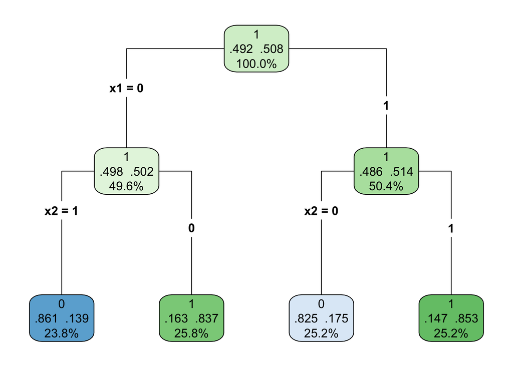

```r
rpart.plot(fit_tree3, type = 4, extra = 104, digits = 3)
```

```r
err <- function(pred, y) mean(pred != y)
c(logit_main = err(predict(fit_logit_main, type = "response") > 0.5, d3$y == "1"),
  logit_int  = err(predict(fit_logit_int,  type = "response") > 0.5, d3$y == "1"),
  tree       = err(predict(fit_tree3, type = "class"), d3$y))
```

```
logit_main  logit_int       tree
     0.320      0.156      0.156
```

**Python**

```python
n = 1000
x1 = np.random.binomial(1, 0.5, n)
x2 = np.random.binomial(1, 0.5, n)
p  = np.where(x1 == x2, 0.85, 0.15)
y  = np.random.binomial(1, p)
X  = np.column_stack([x1, x2])
```

```python
fit_logit_main = LogisticRegression(C = 1e6).fit(X, y)              ## C = 1 / penalty; large C ≈ unpenalised MLE
X_int = np.column_stack([x1, x2, x1 * x2])                          ## add the x1 * x2 interaction column by hand
fit_logit_int  = LogisticRegression(C = 1e6).fit(X_int, y)
fit_tree3      = DecisionTreeClassifier(max_depth = 2).fit(X, y)    ## depth 2 is exactly enough for a 2x2 XOR
```

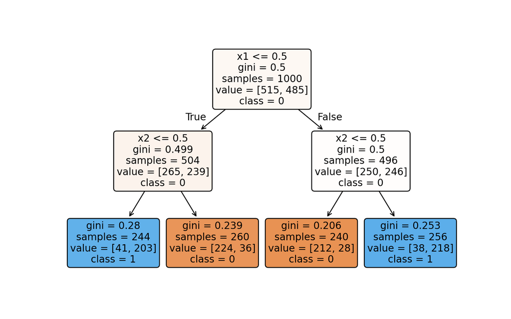

```python
fig, ax = plt.subplots(figsize = (8, 5))
plot_tree(fit_tree3, filled = True, rounded = True,
          feature_names = ["x1", "x2"], class_names = ["0", "1"], ax = ax)
plt.show()
```

```python
{"logit_main": float((fit_logit_main.predict(X)     != y).mean()),
 "logit_int":  float((fit_logit_int.predict(X_int)  != y).mean()),
 "tree":       float((fit_tree3.predict(X)          != y).mean())}
```

```
{'logit_main': 0.305, 'logit_int': 0.143, 'tree': 0.143}
```

**Julia**

```julia
n = 1000;
x1 = rand(0:1, n);
x2 = rand(0:1, n);
p  = ifelse.(x1 .== x2, 0.85, 0.15);
y  = Int.(rand(n) .< p);
X  = hcat(x1, x2);
```

```julia
df3 = DataFrame(x1 = x1, x2 = x2, y = y);
fit_logit_main = glm(@formula(y ~ x1 + x2), df3, Binomial(), LogitLink());   ## main effects only -> blind to XOR
```

```
StatsModels.TableRegressionModel{GeneralizedLinearModel{GLM.GlmResp{Vector{Float64}, Binomial{Float64}, LogitLink}, GLM.DensePredChol{Float64, CholeskyPivoted{Float64, Matrix{Float64}, Vector{Int64}}}}, Matrix{Float64}}

y ~ 1 + x1 + x2

Coefficients:
──────────────────────────────────────────────────────────────────────────
                  Coef.  Std. Error      z  Pr(>|z|)  Lower 95%  Upper 95%
──────────────────────────────────────────────────────────────────────────
(Intercept)  -0.0554226    0.114208  -0.49    0.6275  -0.279265   0.16842
x1           -0.0676008    0.127181  -0.53    0.5951  -0.316871   0.18167
x2            0.0896387    0.126855   0.71    0.4798  -0.158992   0.338269
──────────────────────────────────────────────────────────────────────────
```

```julia
fit_logit_int  = glm(@formula(y ~ x1 * x2), df3, Binomial(), LogitLink());   ## "x1 * x2" expands to x1 + x2 + x1&x2
```

```
StatsModels.TableRegressionModel{GeneralizedLinearModel{GLM.GlmResp{Vector{Float64}, Binomial{Float64}, LogitLink}, GLM.DensePredChol{Float64, CholeskyPivoted{Float64, Matrix{Float64}, Vector{Int64}}}}, Matrix{Float64}}

y ~ 1 + x1 + x2 + x1 & x2

Coefficients:
─────────────────────────────────────────────────────────────────────────
                Coef.  Std. Error       z  Pr(>|z|)  Lower 95%  Upper 95%
─────────────────────────────────────────────────────────────────────────
(Intercept)   2.10515    0.216194    9.74    <1e-21    1.68142    2.52888
x1           -3.75217    0.268542  -13.97    <1e-43   -4.2785    -3.22584
x2           -3.94618    0.286095  -13.79    <1e-42   -4.50692   -3.38544
x1 & x2       7.36154    0.373822   19.69    <1e-85    6.62886    8.09422
─────────────────────────────────────────────────────────────────────────
```

```julia
fit_tree3 = DecisionTreeClassifier(max_depth = 2);                           ## depth 2 is exactly enough for a 2x2 XOR
```

```
DecisionTreeClassifier
max_depth:                2
min_samples_leaf:         1
min_samples_split:        2
min_purity_increase:      0.0
pruning_purity_threshold: 1.0
n_subfeatures:            0
classes:                  nothing
root:                     nothing
```

```julia
DecisionTree.fit!(fit_tree3, X, y);
```

```julia
print_tree(fit_tree3, 3)
```

```
Feature 2 < 1.0 ?
├─ Feature 1 < 1.0 ?
    ├─ 1 : 197/221
    └─ 0 : 244/291
└─ Feature 1 < 1.0 ?
    ├─ 0 : 208/241
    └─ 1 : 211/247
```

```julia
yhat_main = Int.(GLM.predict(fit_logit_main) .> 0.5);
yhat_int  = Int.(GLM.predict(fit_logit_int)  .> 0.5);
yhat_tree = DecisionTree.predict(fit_tree3, X);
(logit_main = mean(yhat_main .!= y),
 logit_int  = mean(yhat_int  .!= y),
 tree       = mean(yhat_tree .!= y))
```

```
(logit_main = 0.663, logit_int = 0.14, tree = 0.14)
```

## 5.1 Exercise 3

Switch to an *unbalanced* XOR: keep $P(Y = 1 \mid x_1 = x_2) = 0.85$, but lower $P(Y = 1 \mid x_1 \ne x_2)$ to $0.40$. Refit the three models and compare error rates again. Then add a **noise variable** $x_3 \sim$ Bernoulli$(0.5)$ that is independent of $Y$, refit the tree, and report which variable it splits on first.

# 6 Application – the Polish Job Vacancy Survey

Now move to the real data set used throughout the course.

**R**

```r
df <- read.csv("data/polish-jvs.csv",
               colClasses = c("character", "factor", rep("character", 4), "numeric"))
df$size        <- factor(df$size, levels = c("Large", "Medium", "Small"))
df$public      <- factor(df$public)
df$nace        <- factor(df$nace)
df$has_vacancy <- as.integer(df$vacancies > 0)
nrow(df)
```

```
[1] 57480
```

**Python**

```python
df = pd.read_csv("data/polish-jvs.csv",
                 dtype = {"id": str, "woj": str, "public": str,
                          "size": str, "nace_division": str, "nace": str})
df["size"]        = pd.Categorical(df["size"], categories = ["Large", "Medium", "Small"])
df["has_vacancy"] = (df["vacancies"] > 0).astype(int)
len(df)
```

```
57480
```

**Julia**

```julia
df = CSV.read("data/polish-jvs.csv", DataFrame,
              types = Dict(:id => String, :woj => String, :public => String,
                           :size => String, :nace_division => String, :nace => String));
df.size        = categorical(df.size, levels = ["Large", "Medium", "Small"]);
df.public      = categorical(df.public);
df.has_vacancy = ifelse.(df.vacancies .> 0, 1, 0);
nrow(df)
```

```
57480
```

The slides show a tree of depth 2 on `has_vacancy` using `size` and `public`. Force the same shape here:

**R**

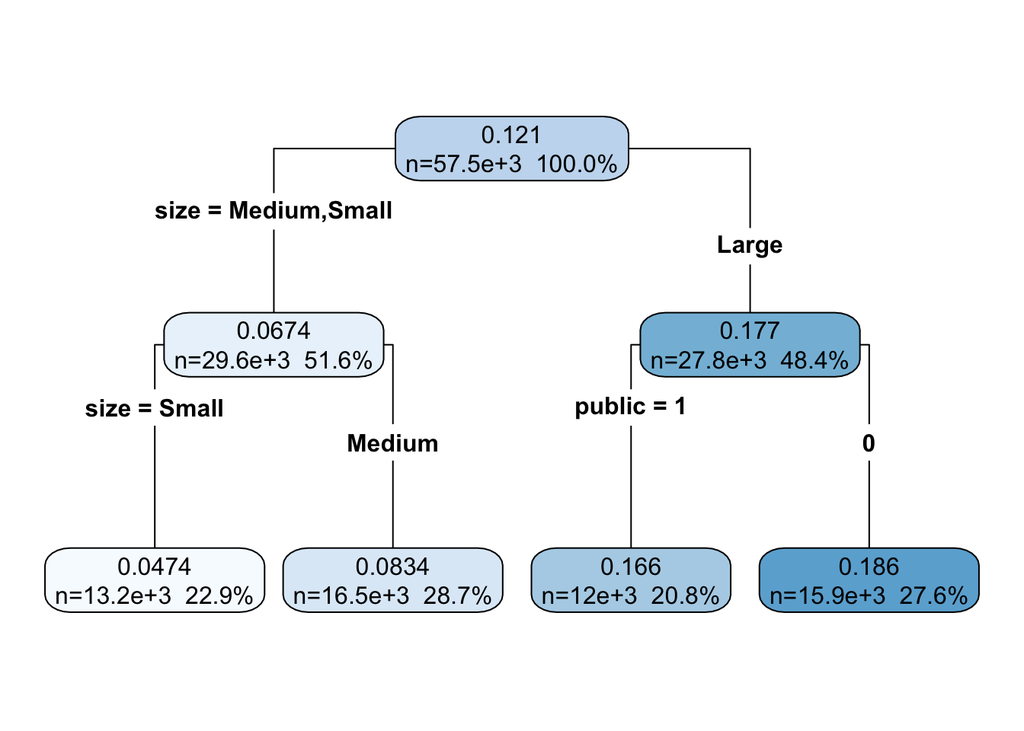

```r
## Gotcha: with method = "class" on a heavily imbalanced binary outcome
## (88% zeros), rpart's cp filter is based on misclassification cost.
## Because no single split flips the majority class in any leaf, every
## split is scored as "zero improvement" and rpart returns the root only.
## Fix: fit as a regression tree on the 0/1 indicator -- for binary Y the
## SSR criterion is equivalent to Gini (var(Y) = p(1 - p) = Gini / 2).
jvs_toy <- rpart(has_vacancy ~ size + public, data = df,
                 method = "anova",                  ## regression on 0/1 = Gini classification for binary Y
                 control = rpart.control(
                   maxdepth = 2,                    ## stop at depth 2 (root = depth 0)
                   cp       = 0))                   ## let depth (not cp) bind; leaf values are p(has_vacancy = 1)
rpart.plot(jvs_toy, type = 4, extra = 101, digits = 3)
```

```r
aggregate(cbind(n = rep(1, nrow(df)),
                p_has = df$has_vacancy,
                mean_vac = df$vacancies)
          ~ size + public, data = df, FUN = sum) -> .agg
within(.agg, {p_has <- p_has / n; mean_vac <- mean_vac / n})
```

| size | public | n | p_has | mean_vac |
| --- | --- | --- | --- | --- |
| Large | 0 | 15873 | 0.1858502 | 2.4374724 |
| Medium | 0 | 10647 | 0.0834977 | 0.2897530 |
| Small | 0 | 10706 | 0.0443676 | 0.0803288 |
| Large | 1 | 11968 | 0.1655247 | 1.2329545 |
| Medium | 1 | 5836 | 0.0832762 | 0.1432488 |
| Small | 1 | 2450 | 0.0604082 | 0.0759184 |

**Python**

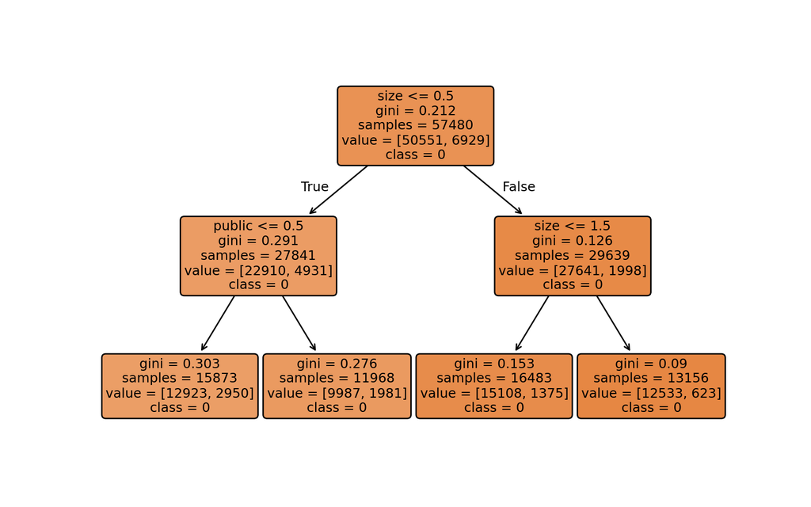

```python
from sklearn.preprocessing import OrdinalEncoder
enc = OrdinalEncoder(categories = [["Large", "Medium", "Small"], ["0", "1"]])
X_toy = enc.fit_transform(df[["size", "public"]].astype(str))
y_toy = df["has_vacancy"].to_numpy()
jvs_toy = DecisionTreeClassifier(max_depth = 2).fit(X_toy, y_toy)   ## depth 2 ⇒ at most 4 leaves; matches the slide
fig, ax = plt.subplots(figsize = (8, 5))
plot_tree(jvs_toy, filled = True, rounded = True,
          feature_names = ["size", "public"], class_names = ["0", "1"], ax = ax)
plt.show()
```

```python
(df.groupby(["size", "public"], observed = True)
   .agg(n = ("has_vacancy", "size"),
        p_has = ("has_vacancy", "mean"),
        mean_vac = ("vacancies", "mean"))
   .round(3))
```

```
                   n  p_has  mean_vac
size   public
Large  0       15873  0.186     2.437
       1       11968  0.166     1.233
Medium 0       10647  0.083     0.290
       1        5836  0.083     0.143
Small  0       10706  0.044     0.080
       1        2450  0.060     0.076
```

**Julia**

```julia
size_code   = levelcode.(df.size);
public_code = levelcode.(df.public);
X_toy = hcat(size_code, public_code);             ## ";" suppresses printing the 57480x2 matrix
```

[output not shown]

```julia
y_toy = df.has_vacancy;
jvs_toy = DecisionTreeClassifier(max_depth = 2)   ## depth 2 ⇒ at most 4 leaves; matches the slide
```

```
DecisionTreeClassifier
max_depth:                2
min_samples_leaf:         1
min_samples_split:        2
min_purity_increase:      0.0
pruning_purity_threshold: 1.0
n_subfeatures:            0
classes:                  nothing
root:                     nothing
```

```julia
DecisionTree.fit!(jvs_toy, X_toy, y_toy);
print_tree(jvs_toy, 3)                            ## second argument = max depth to print (truncates display, not the model)
```

```
Feature 1 < 2.0 ?
├─ Feature 2 < 2.0 ?
    ├─ 0 : 12923/15873
    └─ 0 : 9987/11968
└─ Feature 1 < 3.0 ?
    ├─ 0 : 15108/16483
    └─ 0 : 12533/13156
```

```julia
combine(groupby(df, [:size, :public]),
        nrow => :n,
        :has_vacancy => mean => :p_has,
        :vacancies   => mean => :mean_vac)
```

```
6×5 DataFrame
 Row │ size    public  n      p_has      mean_vac
     │ Cat…    Cat…    Int64  Float64    Float64
─────┼─────────────────────────────────────────────
   1 │ Large   0       15873  0.18585    2.43747
   2 │ Large   1       11968  0.165525   1.23295
   3 │ Medium  0       10647  0.0834977  0.289753
   4 │ Medium  1        5836  0.0832762  0.143249
   5 │ Small   0       10706  0.0443676  0.0803288
   6 │ Small   1        2450  0.0604082  0.0759184
```

The leaf probabilities and means line up with the numbers reported in the slides: Large/private $\approx 0.19$, Large/public $\approx 0.17$, Small or Medium $\approx 0.07$.

## 6.2 Exercise 4

Re-fit the tree **without** the depth restriction (use the default `cp = 0.01`) and let it use `size`, `public`, **and** `nace_division` ($\approx 90$ levels). Report (i) the number of leaves, (ii) the first three variables it splits on, and (iii) the in-sample classification error. Does `nace_division` ever appear in the top of the tree?

# 7 Pruning with cost-complexity

A fully grown tree overfits. CART grows a large tree and prunes it back by minimising
$$R_\alpha(T) \;=\; \sum_{m = 1}^{|T|} \sum_{i \in R_m} \ell(y_i, \hat y_{R_m}) \;+\; \alpha\,|T|.$$

The complexity parameter $\alpha$ is chosen by cross-validation. `rpart` does this for you and stores the CV table in `$cptable`.

**R**

```r
## Same gotcha as above: fit as anova on the 0/1 indicator so that rpart
## actually grows a tree on this heavily imbalanced outcome.
jvs_big <- rpart(has_vacancy ~ size + public + nace_division + woj, data = df,
                 method = "anova",                  ## regression on 0/1; leaf values are p(has_vacancy = 1)
                 control = rpart.control(
                   cp        = 0.0005,              ## very small cp -> grow an over-large tree, prune it back below
                   minbucket = 50))                 ## min 50 obs per leaf, otherwise the deeper splits are unstable
printcp(jvs_big)                                    ## CV table of (cp, |T|, train error, xerror, xstd)
```

```
Regression tree:
rpart(formula = has_vacancy ~ size + public + nace_division +
    woj, data = df, method = "anova", control = rpart.control(cp = 5e-04,
    minbucket = 50))

Variables actually used in tree construction:
[1] nace_division public        size          woj

Root node error: 6093.7/57480 = 0.10601

n= 57480

           CP nsplit rel error  xerror      xstd
1  0.02835142      0   1.00000 1.00001 0.0097219
2  0.02109622      1   0.97165 0.97169 0.0092623
3  0.00437479      2   0.95055 0.95327 0.0090673
4  0.00421998      3   0.94618 0.94888 0.0090465
5  0.00364114      4   0.94196 0.94609 0.0089920
6  0.00219143      5   0.93832 0.94318 0.0089239
7  0.00187427      6   0.93613 0.94201 0.0089358
8  0.00165899      7   0.93425 0.94044 0.0089386
9  0.00133575      8   0.93259 0.93817 0.0089156
10 0.00096688      9   0.93126 0.93767 0.0089122
11 0.00078078     10   0.93029 0.93620 0.0088815
12 0.00068157     11   0.92951 0.93582 0.0088679
13 0.00063641     12   0.92883 0.93538 0.0088604
14 0.00052144     14   0.92755 0.93492 0.0088508
15 0.00050000     15   0.92703 0.93509 0.0088469
```

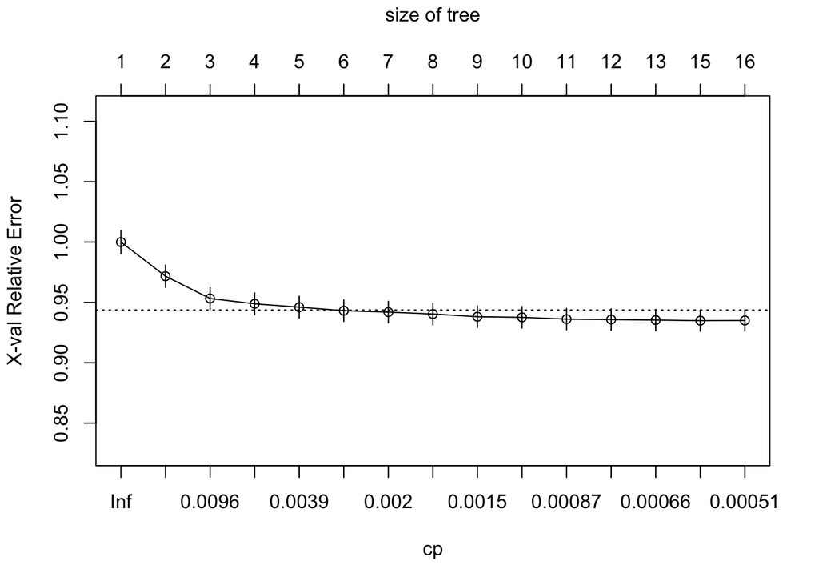

```r
plotcp(jvs_big)                                     ## visualises the same table with the 1-SE bar
```

```r
cp1se <- jvs_big$cptable[, "CP"][which.min(jvs_big$cptable[, "xerror"])]
jvs_pruned <- prune(jvs_big, cp = cp1se)
c(leaves_full   = sum(jvs_big$frame$var == "<leaf>"),
  leaves_pruned = sum(jvs_pruned$frame$var == "<leaf>"))
```

```
  leaves_full leaves_pruned
           16            15
```

**Python**

```python
from sklearn.tree import DecisionTreeClassifier
features_py = ["size", "public", "nace_division", "woj"]
enc_py = OrdinalEncoder(handle_unknown = "use_encoded_value", unknown_value = -1)
X_py   = enc_py.fit_transform(df[features_py].astype(str))
y_py   = df["has_vacancy"].to_numpy()

tree_full = DecisionTreeClassifier(
    min_samples_leaf = 50,        ## min 50 obs per leaf
    random_state     = 123        ## seed for tie-breaking among splits with equal impurity
)
path = tree_full.cost_complexity_pruning_path(X_py, y_py)    ## returns the (alpha, total_impurity) pruning path
alphas = path.ccp_alphas[::max(1, len(path.ccp_alphas) // 20)]   ## subsample ~20 alphas along the path for a quick scan

scores = []
for a in alphas:
    t = DecisionTreeClassifier(
        min_samples_leaf = 50,
        ccp_alpha        = a,     ## cost-complexity pruning weight; sklearn's name for rpart's `cp`
        random_state     = 123
    )
    t.fit(X_py, y_py)
    scores.append({"alpha": float(a),
                   "leaves": int(t.get_n_leaves()),
                   "train_err": float((t.predict(X_py) != y_py).mean())})
```

```
DecisionTreeClassifier(ccp_alpha=6.23494129262628e-05, min_samples_leaf=50,
                       random_state=123)
```

```python
pd.DataFrame(scores)
```

```
           alpha  leaves  train_err
0   0.000000e+00     645   0.119607
1   1.443099e-08     624   0.119607
2   1.506202e-07     601   0.119607
3   3.119755e-07     577   0.119607
4   4.736384e-07     551   0.119607
5   6.890233e-07     527   0.119607
6   1.031106e-06     502   0.119607
7   1.526466e-06     476   0.119607
8   1.989465e-06     450   0.119607
9   2.340645e-06     421   0.119607
10  2.939312e-06     392   0.119607
11  3.610649e-06     356   0.119607
12  4.252964e-06     326   0.119607
13  5.049200e-06     285   0.119607
14  6.261863e-06     253   0.119607
15  7.490310e-06     221   0.119607
16  1.033429e-05     180   0.119607
17  1.315837e-05     140   0.119607
18  1.924513e-05     107   0.119607
19  2.982325e-05      75   0.119607
20  6.234941e-05      34   0.119607
```

**Julia**

```julia
size_c = levelcode.(df.size);
pub_c  = levelcode.(df.public);
nace_c = levelcode.(categorical(df.nace_division));
woj_c  = levelcode.(categorical(df.woj));
X_full = hcat(size_c, pub_c, nace_c, woj_c);          ## ";" suppresses the big matrix print
```

[output not shown]

```julia
y_full = df.has_vacancy;

depths = [2, 4, 6, 8, 10]
```

```
5-element Vector{Int64}:
  2
  4
  6
  8
 10
```

```julia
results = DataFrame(max_depth = Int[], train_err = Float64[])
```

```
0×2 DataFrame
 Row │ max_depth  train_err
     │ Int64      Float64
─────┴──────────────────────
```

```julia
for d in depths
    t = DecisionTreeClassifier(
        max_depth        = d,    ## sweep depth as a proxy for cost-complexity pruning (DecisionTree.jl has no ccp_alpha)
        min_samples_leaf = 50    ## min 50 obs per leaf
    )
    DecisionTree.fit!(t, X_full, y_full)
    push!(results, (d, mean(DecisionTree.predict(t, X_full) .!= y_full)))
end
results
```

```
5×2 DataFrame
 Row │ max_depth  train_err
     │ Int64      Float64
─────┼──────────────────────
   1 │         2   0.120546
   2 │         4   0.120546
   3 │         6   0.119607
   4 │         8   0.119607
   5 │        10   0.119607
```

## 7.1 Exercise 5

Fit a **regression tree** for `vacancies` (not `has_vacancy`) with `method = "anova"` and the same predictors. Plot the pruning curve and select the tree at the 1-SE rule. What is the MSE of this pruned tree compared to a Poisson GLM with the same predictors?

# 8 Conditional inference trees and ensembles (teaser)

Two extensions that fix the biggest weakness of CART (selection bias toward high-cardinality predictors and high variance of a single tree):

- **Conditional inference trees** (`partykit::ctree`) – decouple variable selection from split selection by using permutation tests.
- **Random forest** – average many trees fit on bootstrap samples with a random subset of predictors at each split.

**R**

```r
ct <- partykit::ctree(factor(has_vacancy) ~ size + public + nace,
                      data = df,
                      control = partykit::ctree_control(
                        maxdepth     = 3,           ## maximum tree depth
                        mincriterion = 0.99))       ## 1 - p-value cut-off; only split when the permutation test p < 0.01
print(ct)
```

```
Model formula:
factor(has_vacancy) ~ size + public + nace

Fitted party:
[1] root
|   [2] nace in A, B, D, E, F, G, H, I, J, K, L, M, N, P, Q, R, S
|   |   [3] size in Large
|   |   |   [4] nace in A, B, E, K, P, R: 0 (n = 8826, err = 8.6%)
|   |   |   [5] nace in D, F, G, H, I, J, L, M, N, Q, S: 0 (n = 11599, err = 18.9%)
|   |   [6] size in Medium, Small
|   |   |   [7] size in Medium: 0 (n = 14835, err = 7.8%)
|   |   |   [8] size in Small: 0 (n = 11796, err = 4.1%)
|   [9] nace in C, O
|   |   [10] size in Large
|   |   |   [11] public in 0: 0 (n = 5206, err = 24.1%)
|   |   |   [12] public in 1: 0 (n = 2210, err = 32.5%)
|   |   [13] size in Medium, Small
|   |   |   [14] nace in C: 0 (n = 1765, err = 9.6%)
|   |   |   [15] nace in O: 0 (n = 1243, err = 15.2%)

Number of inner nodes:    7
Number of terminal nodes: 8
```

**Python**

```python
from sklearn.ensemble import RandomForestClassifier
rf = RandomForestClassifier(
    n_estimators     = 200,   ## number of bootstrap trees in the forest
    min_samples_leaf = 50,    ## min 50 obs per leaf in every tree
    random_state     = 123,   ## seed for bootstrapping and the random feature subset at each split
    n_jobs           = -1     ## -1 = use all available CPU cores
).fit(X_py, y_py)
imp = pd.Series(rf.feature_importances_, index = features_py).sort_values(ascending = False)
imp.round(3)
```

```
nace_division    0.466
size             0.331
woj              0.179
public           0.024
dtype: float64
```

**Julia**

```julia
rf = RandomForestClassifier(
    n_trees          = 200,    ## number of trees in the forest
    partial_sampling = 0.7,    ## fraction of training rows used to grow each tree (bootstrap subsample fraction)
    min_samples_leaf = 50      ## min 50 obs per leaf in every tree
);
DecisionTree.fit!(rf, X_full, y_full);
mean(DecisionTree.predict(rf, X_full) .!= y_full)
```

```
0.11960681976339596
```

## 8.1 Exercise 6

Compare a **single classification tree**, a **random forest**, and a **logistic regression** on the same set of predictors. Split the JVS data into a 70/30 train-test split, fit each model on the training set, and report **test-set accuracy** and **AUC** for each. Which model wins?

# 9 Further reading

- **Textbook.** Hastie, T., Tibshirani, R., & Friedman, J. (2009). *The Elements of Statistical Learning* (2nd ed.), Chapter 9. Springer. doi:10.1007/978-0-387-84858-7.
- **Gentle introduction.** James, G., Witten, D., Hastie, T., & Tibshirani, R. (2021). *An Introduction to Statistical Learning* (2nd ed.), Chapter 8. Springer. doi:10.1007/978-1-0716-1418-1.
- **Original reference.** Breiman, L., Friedman, J. H., Olshen, R. A., & Stone, C. J. (1984). *Classification and Regression Trees*. Wadsworth.
- **R packages.** Therneau, T. & Atkinson, B. – `rpart` vignette on CRAN; Hothorn, T., Hornik, K., & Zeileis, A. (2006). Unbiased recursive partitioning. *JCGS*, 15(3), 651–674. doi:10.1198/106186006X133933 – the `partykit::ctree` paper.
- **Ensembles.** Breiman, L. (2001). Random forests. *Machine Learning*, 45(1), 5–32. doi:10.1023/A:1010933404324. Friedman, J. H. (2001). Greedy function approximation: A gradient boosting machine. *Annals of Statistics*, 29(5), 1189–1232. doi:10.1214/aos/1013203451. Chen, T., & Guestrin, C. (2016). XGBoost. *KDD ’16*, 785–794. doi:10.1145/2939672.2939785.
- **Fifty-year retrospective.** Loh, W.-Y. (2014). Fifty years of classification and regression trees. *International Statistical Review*, 82(3), 329–348. doi:10.1111/insr.12016.

# 10 Script files

The code for this document can be found here:

- 11-trees.jl
- 11-trees.sh
- 11-trees.R
- 11-trees.py